# Bikesbigdata

Sergio Medina

2024-10-15

#Biking project case of study#

## 1.Company goal

Ultimate goal is to Desing marketing strategies aimed at converting casual riders into annual members.

## 2.Bussiness task

The question we are trying to solve is How annual members and casual members differ, how they use bikes differently? we can analyze the cyclistic histocial bike trip data to identify trends or patterns that way we can help stake holders to resolve this question.

##3.Prepare Where is the data located? we got multiple .csv files are going to explore how data is organized for that we will load the first file after loading the require packages

```r
#install.packages("tidyverse")
library(tidyverse)
library(conflicted)
conflict_prefer("filter","dplyr")
```

```
## [conflicted] Will prefer dplyr::filter over any other package.
```

```r
conflict_prefer("lag","dplyr")
```

```
## [conflicted] Will prefer dplyr::lag over any other package.
```

```r
library(ggplot2)
library(dplyr)
library(readr)
```

Over here we load the .csv last quarter 3 months and see how data is organized with the following code

```r
#load CSV here collect the data
bikes_m1<-read.csv("202401-divvy-tripdata.csv")
bikes_m2<-read.csv("202402-divvy-tripdata.csv")
bikes_m3<-read.csv("202403-divvy-tripdata.csv")

#head(bikes_m1)

#here we preview the datasets
str(bikes_m1)
```

```
## 'data.frame':    144873 obs. of  13 variables:
##  $ ride_id           : chr  "C1D650626C8C899A" "EECD38BDB25BFCB0" "F4A9CE78061F17F7" "0A0D9E15EE50B171" ...
##  $ rideable_type     : chr  "electric_bike" "electric_bike" "electric_bike" "classic_bike" ...
##  $ started_at        : chr  "2024-01-12 15:30:27" "2024-01-08 15:45:46" "2024-01-27 12:27:19" "2024-01-29 16:26:17" ...
##  $ ended_at          : chr  "2024-01-12 15:37:59" "2024-01-08 15:52:59" "2024-01-27 12:35:19" "2024-01-29 16:56:06" ...
##  $ start_station_name: chr  "Wells St & Elm St" "Wells St & Elm St" "Wells St & Elm St" "Wells St & Randolph St" ...
##  $ start_station_id  : chr  "KA1504000135" "KA1504000135" "KA1504000135" "TA1305000030" ...
##  $ end_station_name  : chr  "Kingsbury St & Kinzie St" "Kingsbury St & Kinzie St" "Kingsbury St & Kinzie St" "Larrabee St & Webster Ave" ...
##  $ end_station_id    : chr  "KA1503000043" "KA1503000043" "KA1503000043" "13193" ...
##  $ start_lat         : num  41.9 41.9 41.9 41.9 41.9 ...
##  $ start_lng         : num  -87.6 -87.6 -87.6 -87.6 -87.7 ...
##  $ end_lat           : num  41.9 41.9 41.9 41.9 41.9 ...
##  $ end_lng           : num  -87.6 -87.6 -87.6 -87.6 -87.6 ...
##  $ member_casual     : chr  "member" "member" "member" "member" ...
```

```r
str(bikes_m2)
```

```
## 'data.frame':    223164 obs. of  13 variables:
##  $ ride_id           : chr  "FCB05EB1758F85E8" "7FB986AD5D3DE9D6" "40CA13E15B5B470D" "D47A1660919E8861" ...
##  $ rideable_type     : chr  "classic_bike" "classic_bike" "electric_bike" "classic_bike" ...
##  $ started_at        : chr  "2024-02-03 14:14:18" "2024-02-05 21:10:06" "2024-02-05 15:10:44" "2024-02-15 12:40:34" ...
##  $ ended_at          : chr  "2024-02-03 14:21:00" "2024-02-05 21:15:44" "2024-02-05 15:12:32" "2024-02-15 12:44:24" ...
##  $ start_station_name: chr  "Clark St & Newport St" "Michigan Ave & Washington St" "Leavitt St & Armitage Ave" "Southport Ave & Waveland Ave" ...
##  $ start_station_id  : chr  "632" "13001" "TA1309000029" "13235" ...
##  $ end_station_name  : chr  "Southport Ave & Waveland Ave" "Wabash Ave & Grand Ave" "Milwaukee Ave & Wabansia Ave" "Southport Ave & Belmont Ave" ...
##  $ end_station_id    : chr  "13235" "TA1307000117" "13243" "13229" ...
##  $ start_lat         : num  41.9 41.9 41.9 41.9 41.8 ...
##  $ start_lng         : num  -87.7 -87.6 -87.7 -87.7 -87.6 ...
##  $ end_lat           : num  41.9 41.9 41.9 41.9 41.8 ...
##  $ end_lng           : num  -87.7 -87.6 -87.7 -87.7 -87.6 ...
##  $ member_casual     : chr  "member" "member" "member" "member" ...
```

```r
str(bikes_m3)
```

```
## 'data.frame':    301687 obs. of  13 variables:
##  $ ride_id           : chr  "64FBE3BAED5F29E6" "9991629435C5E20E" "E5C9FECD5B71BEBD" "4CEA3EC8906DAEA8" ...
##  $ rideable_type     : chr  "electric_bike" "electric_bike" "electric_bike" "electric_bike" ...
##  $ started_at        : chr  "2024-03-05 18:33:11" "2024-03-06 17:15:14" "2024-03-06 17:16:36" "2024-03-03 22:55:54" ...
##  $ ended_at          : chr  "2024-03-05 18:51:48" "2024-03-06 17:16:04" "2024-03-06 17:19:28" "2024-03-03 22:58:08" ...
##  $ start_station_name: chr  "" "" "" "" ...
##  $ start_station_id  : chr  "" "" "" "" ...
##  $ end_station_name  : chr  "" "" "" "" ...
##  $ end_station_id    : chr  "" "" "" "" ...
##  $ start_lat         : num  41.9 41.9 41.9 41.9 41.9 ...
##  $ start_lng         : num  -87.7 -87.6 -87.6 -87.6 -87.7 ...
##  $ end_lat           : num  42 41.9 41.9 41.9 41.9 ...
##  $ end_lng           : num  -87.7 -87.6 -87.6 -87.6 -87.7 ...
##  $ member_casual     : chr  "member" "member" "member" "member" ...
```

```r
#glimpse(bikes_m1)
```

We see we are dealing with a very large dataset, we compare the names of the columns to see if they are all the same

```r
#comparing columns names here
colnames(bikes_m1)
```

```
##  [1] "ride_id"            "rideable_type"      "started_at"
##  [4] "ended_at"           "start_station_name" "start_station_id"
##  [7] "end_station_name"   "end_station_id"     "start_lat"
## [10] "start_lng"          "end_lat"            "end_lng"
## [13] "member_casual"
```

```r
colnames(bikes_m2)
```

```
##  [1] "ride_id"            "rideable_type"      "started_at"
##  [4] "ended_at"           "start_station_name" "start_station_id"
##  [7] "end_station_name"   "end_station_id"     "start_lat"
## [10] "start_lng"          "end_lat"            "end_lng"
## [13] "member_casual"
```

```r
colnames(bikes_m3)
```

```
##  [1] "ride_id"            "rideable_type"      "started_at"
##  [4] "ended_at"           "start_station_name" "start_station_id"
##  [7] "end_station_name"   "end_station_id"     "start_lat"
## [10] "start_lng"          "end_lat"            "end_lng"
## [13] "member_casual"
```

##4.Data Procces All columns names are the same so we proceed to stacks each data frame into a big data frame

```r
all_trips<- bind_rows(bikes_m1,bikes_m2,bikes_m3) #bigger dataset Qx
#we preview the dataset
str(all_trips)
```

```
## 'data.frame':    669724 obs. of  13 variables:
##  $ ride_id           : chr  "C1D650626C8C899A" "EECD38BDB25BFCB0" "F4A9CE78061F17F7" "0A0D9E15EE50B171" ...
##  $ rideable_type     : chr  "electric_bike" "electric_bike" "electric_bike" "classic_bike" ...
##  $ started_at        : chr  "2024-01-12 15:30:27" "2024-01-08 15:45:46" "2024-01-27 12:27:19" "2024-01-29 16:26:17" ...
##  $ ended_at          : chr  "2024-01-12 15:37:59" "2024-01-08 15:52:59" "2024-01-27 12:35:19" "2024-01-29 16:56:06" ...
##  $ start_station_name: chr  "Wells St & Elm St" "Wells St & Elm St" "Wells St & Elm St" "Wells St & Randolph St" ...
##  $ start_station_id  : chr  "KA1504000135" "KA1504000135" "KA1504000135" "TA1305000030" ...
##  $ end_station_name  : chr  "Kingsbury St & Kinzie St" "Kingsbury St & Kinzie St" "Kingsbury St & Kinzie St" "Larrabee St & Webster Ave" ...
##  $ end_station_id    : chr  "KA1503000043" "KA1503000043" "KA1503000043" "13193" ...
##  $ start_lat         : num  41.9 41.9 41.9 41.9 41.9 ...
##  $ start_lng         : num  -87.6 -87.6 -87.6 -87.6 -87.7 ...
##  $ end_lat           : num  41.9 41.9 41.9 41.9 41.9 ...
##  $ end_lng           : num  -87.6 -87.6 -87.6 -87.6 -87.6 ...
##  $ member_casual     : chr  "member" "member" "member" "member" ...
```

we then need to remove unnecessary data columns data like the latitude info

```r
#here we remove unnecessary columns
all_trips<- all_trips %>%
  select(-c(start_lat,start_lng,end_lat,end_lng))
colnames(all_trips)
```

```
## [1] "ride_id"            "rideable_type"      "started_at"
## [4] "ended_at"           "start_station_name" "start_station_id"
## [7] "end_station_name"   "end_station_id"     "member_casual"
```

```r
dim(all_trips) # dimensions of the data frame
```

```
## [1] 669724      9
```

```r
summary(all_trips) #statistical summary
```

```
##    ride_id          rideable_type       started_at          ended_at
##  Length:669724      Length:669724      Length:669724      Length:669724
##  Class :character   Class :character   Class :character   Class :character
##  Mode  :character   Mode  :character   Mode  :character   Mode  :character
##  start_station_name start_station_id   end_station_name   end_station_id
##  Length:669724      Length:669724      Length:669724      Length:669724
##  Class :character   Class :character   Class :character   Class :character
##  Mode  :character   Mode  :character   Mode  :character   Mode  :character
##  member_casual
##  Length:669724
##  Class :character
##  Mode  :character
```

over here we analyze the data to clean it and add new interesting info

```r
unique(all_trips$member_casual) #run this to check is there are some data errors
```

```
## [1] "member" "casual"
```

```r
table(all_trips$member_casual) # we run this to check how much members are and how much casuals
```

```
##
## casual member
## 154173 515551
```

```r
#we add columns to know the date month day year and day of the week
all_trips$date<- as.Date(all_trips$started_at)
all_trips$month<- format(as.Date(all_trips$date),"%m")
all_trips$day<- format(as.Date(all_trips$date),"%d")
all_trips$year<- format(as.Date(all_trips$date),"%Y")
all_trips$day_of_week<- format(as.Date(all_trips$date),"%A")
#then we add the ride_length calculation to all trips in seconds
all_trips$ride_length<-difftime(all_trips$ended_at,all_trips$started_at)
# then we Inspect the structure of the columns
str(all_trips)
```

```
## 'data.frame':    669724 obs. of  15 variables:
##  $ ride_id           : chr  "C1D650626C8C899A" "EECD38BDB25BFCB0" "F4A9CE78061F17F7" "0A0D9E15EE50B171" ...
##  $ rideable_type     : chr  "electric_bike" "electric_bike" "electric_bike" "classic_bike" ...
##  $ started_at        : chr  "2024-01-12 15:30:27" "2024-01-08 15:45:46" "2024-01-27 12:27:19" "2024-01-29 16:26:17" ...
##  $ ended_at          : chr  "2024-01-12 15:37:59" "2024-01-08 15:52:59" "2024-01-27 12:35:19" "2024-01-29 16:56:06" ...
##  $ start_station_name: chr  "Wells St & Elm St" "Wells St & Elm St" "Wells St & Elm St" "Wells St & Randolph St" ...
##  $ start_station_id  : chr  "KA1504000135" "KA1504000135" "KA1504000135" "TA1305000030" ...
##  $ end_station_name  : chr  "Kingsbury St & Kinzie St" "Kingsbury St & Kinzie St" "Kingsbury St & Kinzie St" "Larrabee St & Webster Ave" ...
##  $ end_station_id    : chr  "KA1503000043" "KA1503000043" "KA1503000043" "13193" ...
##  $ member_casual     : chr  "member" "member" "member" "member" ...
##  $ date              : Date, format: "2024-01-12" "2024-01-08" ...
##  $ month             : chr  "01" "01" "01" "01" ...
##  $ day               : chr  "12" "08" "27" "29" ...
##  $ year              : chr  "2024" "2024" "2024" "2024" ...
##  $ day_of_week       : chr  "Friday" "Monday" "Saturday" "Monday" ...
##  $ ride_length       : 'difftime' num  452 433 480 1789 ...
##   ..- attr(*, "units")= chr "secs"
```

After this we make some finals adjustments to the data

```r
# we Convert "ride_length" from Factor to numeric so we can run calculations on the data
is.factor(all_trips$ride_length)
```

```
## [1] FALSE
```

```r
all_trips$ride_length <- as.numeric(as.character(all_trips$ride_length))
is.numeric(all_trips$ride_length)
```

```
## [1] TRUE
```

```r
#here we remove bad data negative values, created a new version because data is being removed
all_trips_v2 <- all_trips[!(all_trips$start_station_name == "HQ QR" | all_trips$ride_length<0),]
#here we drop any null values in the colum members_casual
all_trips_v2 %>% drop_na(member_casual)
```

[output not shown]

[output cut: 26654 more lines]

##5.Data analysis Then we can starts doing some statistics of the data

```r
summary(all_trips_v2$ride_length)
```

```
##    Min. 1st Qu.  Median    Mean 3rd Qu.    Max.
##     0.0   290.0   488.0   925.1   846.0 93596.0
```

```r
#here we compare members and casual users
aggregate(all_trips_v2$ride_length ~ all_trips_v2$member_casual, FUN = mean)
```

```
##   all_trips_v2$member_casual all_trips_v2$ride_length
## 1                     casual                1467.0645
## 2                     member                 763.0919
```

```r
aggregate(all_trips_v2$ride_length ~ all_trips_v2$member_casual, FUN = median)
```

```
##   all_trips_v2$member_casual all_trips_v2$ride_length
## 1                     casual                      588
## 2                     member                      464
```

```r
aggregate(all_trips_v2$ride_length ~ all_trips_v2$member_casual, FUN = max)
```

```
##   all_trips_v2$member_casual all_trips_v2$ride_length
## 1                     casual                    93596
## 2                     member                    93588
```

```r
aggregate(all_trips_v2$ride_length ~ all_trips_v2$member_casual, FUN = min)
```

```
##   all_trips_v2$member_casual all_trips_v2$ride_length
## 1                     casual                        0
## 2                     member                        0
```

```r
#here we see the average ride time by each day for members vs casual users
aggregate(all_trips_v2$ride_length ~ all_trips_v2$member_casual + all_trips_v2$day_of_week,
FUN = mean)
```

```
##    all_trips_v2$member_casual all_trips_v2$day_of_week all_trips_v2$ride_length
## 1                      casual                   Friday                1364.7744
## 2                      member                   Friday                 705.1346
## 3                      casual                   Monday                1503.9152
## 4                      member                   Monday                 747.3163
## 5                      casual                 Saturday                1708.8232
## 6                      member                 Saturday                 810.7339
## 7                      casual                   Sunday                1764.2515
## 8                      member                   Sunday                 842.0577
## 9                      casual                 Thursday                1178.0533
## 10                     member                 Thursday                 718.0557
## 11                     casual                  Tuesday                1429.0729
## 12                     member                  Tuesday                 777.3634
## 13                     casual                Wednesday                1178.4410
## 14                     member                Wednesday                 774.1319
```

we notice that the days of the week are out of orders we fix that

```r
# Notice that the days of the week are out of order. Let's fix that.
all_trips_v2$day_of_week <- ordered(all_trips_v2$day_of_week, levels=c("Sunday", "Monday",
"Tuesday", "Wednesday", "Thursday", "Friday", "Saturday"))
# Now, let's run the average ride time by each day for members vs casual users
aggregate(all_trips_v2$ride_length ~ all_trips_v2$member_casual + all_trips_v2$day_of_week,
FUN = mean)
```

```
##    all_trips_v2$member_casual all_trips_v2$day_of_week all_trips_v2$ride_length
## 1                      casual                   Sunday                1764.2515
## 2                      member                   Sunday                 842.0577
## 3                      casual                   Monday                1503.9152
## 4                      member                   Monday                 747.3163
## 5                      casual                  Tuesday                1429.0729
## 6                      member                  Tuesday                 777.3634
## 7                      casual                Wednesday                1178.4410
## 8                      member                Wednesday                 774.1319
## 9                      casual                 Thursday                1178.0533
## 10                     member                 Thursday                 718.0557
## 11                     casual                   Friday                1364.7744
## 12                     member                   Friday                 705.1346
## 13                     casual                 Saturday                1708.8232
## 14                     member                 Saturday                 810.7339
```

Now we can analyze average ride time by each day for members vs casual users

```r
# analyze ridership data by type and weekday
all_trips_v2 %>%
mutate(weekday = wday(started_at, label = TRUE)) %>% #creates weekday field using wday()
group_by(member_casual, weekday ) %>%  #groups by usertype and weekday
summarise(number_of_rides = n() #calculates the number of rides and average duration
        ,average_duration = mean(ride_length)) %>% # calculates the average duration
arrange(member_casual, weekday) # sorts
```

```
## # A tibble: 14 × 4
## # Groups:   member_casual [2]
##    member_casual weekday number_of_rides average_duration
##    <chr>         <ord>             <int>            <dbl>
##  1 casual        Sun               24326            1764.
##  2 casual        Mon               20777            1504.
##  3 casual        Tue               20903            1429.
##  4 casual        Wed               20043            1178.
##  5 casual        Thu               21193            1178.
##  6 casual        Fri               19276            1365.
##  7 casual        Sat               27634            1709.
##  8 member        Sun               52180             842.
##  9 member        Mon               78369             747.
## 10 member        Tue               84945             777.
## 11 member        Wed               89270             774.
## 12 member        Thu               88966             718.
## 13 member        Fri               65130             705.
## 14 member        Sat               56662             811.
```

Finally we can also get the number of rides and average duration per month

```r
all_trips_v2 %>%
group_by(member_casual, month, rideable_type) %>%  #groups by usertype and month
summarise(number_of_rides = n() #calculates the number of rides and average duration
        ,average_duration = mean(ride_length)) %>% # calculates the average duration
arrange(member_casual, month) # sorts
```

```
## # A tibble: 12 × 5
## # Groups:   member_casual, month [6]
##    member_casual month rideable_type number_of_rides average_duration
##    <chr>         <chr> <chr>                   <int>            <dbl>
##  1 casual        01    classic_bike            10451            2249.
##  2 casual        01    electric_bike           14007             554.
##  3 casual        02    classic_bike            27811            2069.
##  4 casual        02    electric_bike           19350             711.
##  5 casual        03    classic_bike            39614            2288.
##  6 casual        03    electric_bike           42919             768.
##  7 member        01    classic_bike            66073            1030.
##  8 member        01    electric_bike           54322             581.
##  9 member        02    classic_bike           112503             846.
## 10 member        02    electric_bike           63495             649.
## 11 member        03    classic_bike           108970             834.
## 12 member        03    electric_bike          110159             603.
```

##5.Share data with visualization Now we can start doing some plots

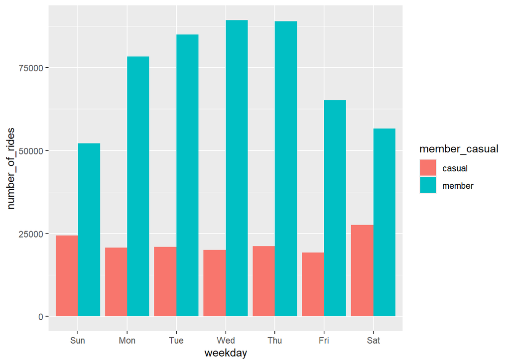

```r
# Let's visualize the number of rides by rider type
all_trips_v2 %>%
mutate(weekday = wday(started_at, label = TRUE)) %>%
group_by(member_casual, weekday) %>%
  summarise(number_of_rides = n()
,average_duration = mean(ride_length)) %>%
arrange(member_casual, weekday) %>%
ggplot(aes(x = weekday, y = number_of_rides, fill = member_casual)) +
geom_col(position = "dodge")
```

Finally we get the average duration

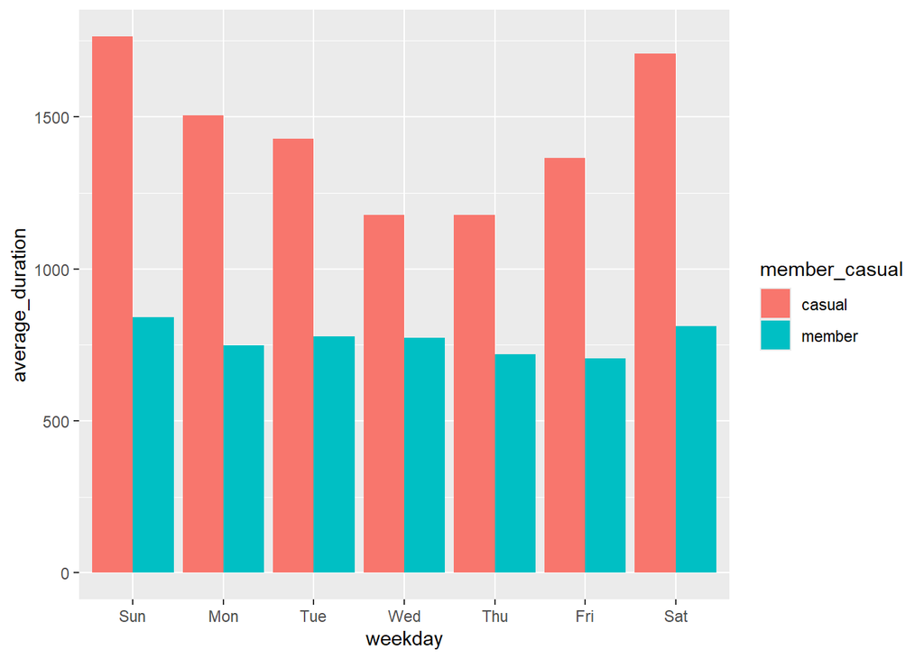

```r
# Let's create a visualization for average duration
all_trips_v2 %>%
mutate(weekday = wday(started_at, label = TRUE)) %>%
group_by(member_casual, weekday) %>%
summarise(number_of_rides = n()
,average_duration = mean(ride_length)) %>%
arrange(member_casual, weekday) %>%
ggplot(aes(x = weekday, y = average_duration, fill = member_casual)) +
geom_col(position = "dodge")
```

we group by month to see if there is any different pattern in the same variables for the numbers of rides

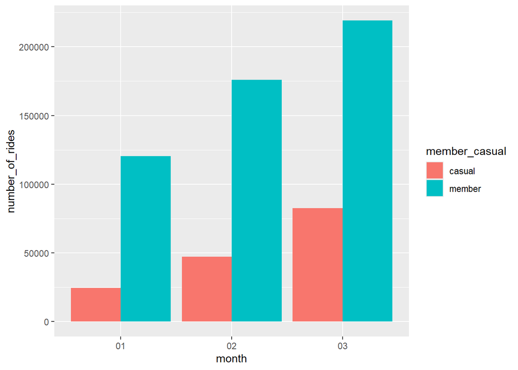

```r
all_trips_v2 %>%
group_by(member_casual, month) %>%
  summarise(number_of_rides = n()
,average_duration = mean(ride_length)) %>%
arrange(member_casual, month) %>%
ggplot(aes(x = month, y = number_of_rides, fill = member_casual)) +
geom_col(position = "dodge")
```

for the average duration

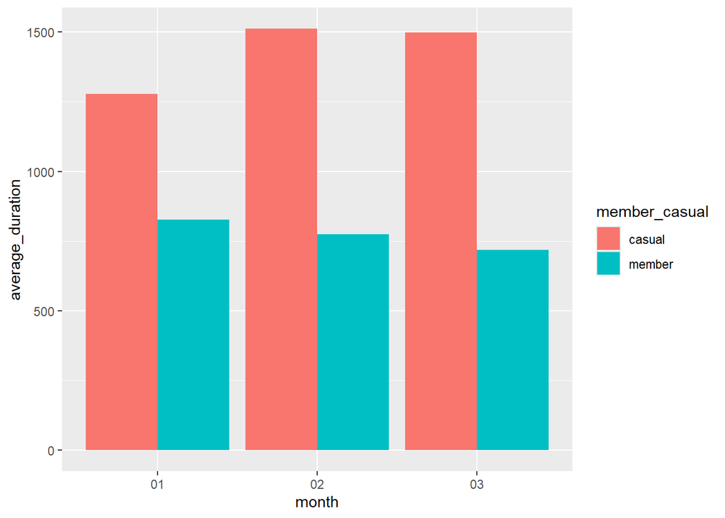

```r
#
all_trips_v2 %>%
group_by(member_casual, month) %>%
summarise(number_of_rides = n()
,average_duration = mean(ride_length)) %>%
arrange(member_casual, month) %>%
ggplot(aes(x = month, y = average_duration, fill = member_casual)) +
geom_col(position = "dodge")
```

Finally we check if the casual members use more electrical bikes or classicals we see here if casual riders use more the electric bikes or the classic bikes compared to the members

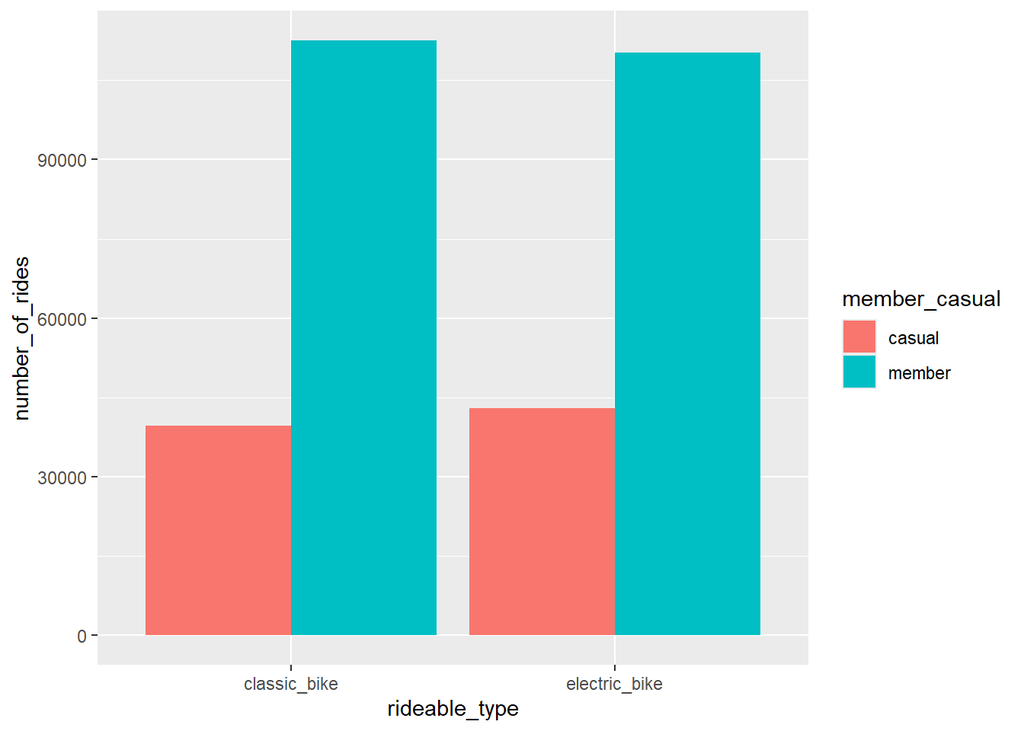

```r
all_trips_v2 %>%
group_by(member_casual, month, rideable_type) %>%
  summarise(number_of_rides = n()
,average_duration = mean(ride_length)) %>%
arrange(member_casual, month, rideable_type) %>%
ggplot(aes(x = rideable_type, y = number_of_rides, fill = member_casual)) +
geom_col(position = "dodge")
```

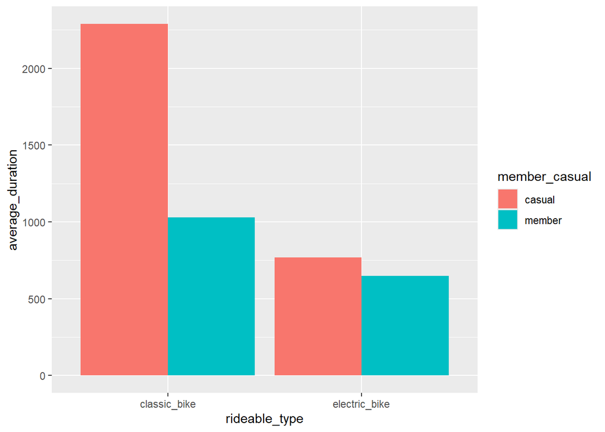

```r
all_trips_v2 %>%
group_by(member_casual, month, rideable_type) %>%
summarise(number_of_rides = n()
,average_duration = mean(ride_length)) %>%
arrange(member_casual, month, rideable_type) %>%
ggplot(aes(x = rideable_type, y = average_duration, fill = member_casual)) +
geom_col(position = "dodge")
```